# Ejemplo de estilo de documento en Quarto

Inspirado en Tufte Handout, usando Quarto

Fecha de publicación

24 de octubre de 2024

# Introducción

Este documento demuestra el uso de unas cuantas características avanzadas para configurar el estilo y la maquetación visual de las páginas en Quarto, con el objetivo de producir un documento atractivo y práctico inspirado en el estilo de entregas de Edward R. Tufte. Dicho estilo ya se implementó con éxito en los documentos con RMarkdown (Xie, Allaire, y Grolemund 2018), la tecnología que ha precedido a Quarto. Este estilo es el que utilizaba Tufte en sus entregables y sus libros, y es conocido por su uso intensivo de notas al margen, la estrecha integración de los gráficos con el texto y una tipografía muy cuidada. Quarto soporta muchas de las técnicas de diseño gráfico que se utilizan en el estilo de entregas Tufte, tanto para documentos HTML como en LaTeX/PDF.

Xie, Yihui, J. J. Allaire, y Garrett Grolemund. 2018. «Tufte Handouts». En *R Markdown: The Definitive Guide*, 137-46. Chapman; Hall/CRC. https://doi.org/10.1201/9781138359444-6.

<sup>1</sup> Here is the footnote.

<sup>2</sup> Here’s one with multiple blocks.

Here is a footnote reference,[^1] and another[^2].

Veamos un ejemplo de las opciones básicas de debemos configurar en la cabecera de nuestro documento para utilizar este diseño en particular.

```yaml
---
title: "Ejemplo de documento con el estilo Tufte"
author: "John Doe"
format:
  html:
    grid:
      margin-width: 350px
  pdf: default
reference-location: margin
citation-location: margin
---
```

**1**

Esta opción incrementa el ancho del margen de la página, para dejar más espacio para notas y figuras al margen (sólo válido en HTML).

**2**

Coloca las notas al pie y las citas bibliográficas en el margen lateral. Otras opciones de diseño gráfico y maquetación (por ejemplo, colocar figuras en el margen) se configurarán para cada elemento en los ejemplos a continuación.

Estas características de diseño están concebidas con dos importantes objetivos en mente:

1. Producir tanto salida en HTML como en PDF con un estilo similar y elementos homogéneos usando el mismo documento Quarto como fuente.
2. Proporcionar una sintaxis sencilla para escribir elementos siguiendo el estilo Tufte, tales como notas y figuras al margen. Por ejemplo, si se quiere colocar una figura en el margen sólo hay que añadir la opción `fig-column: margin` en el bloque de código y Quarto se encargará del resto del trabajo[^3].

<sup>3</sup> Nunca deberías tener que pensar en introducir configuraciones específicas para cada salida, como `\begin{marginfigure}` en LaTeX o `<span class="marginfigure">` en HTML; el código de LaTeX o HTML para producir cada elemento gráfico internamente puede ser complicado de recordar, así que el usuario de Quarto no debería tener que bajar nunca a ese nivel.

Se pueden enviar informes de error o solicitudes de nuevas características a través de la URL: https://github.com/quarto-dev/quarto-cli/issues.

# Figuras

## Figuras al margen

Las imágenes y los gráficos juegan un papel integral en la propuesta de diseño de Tufte. Para colocar las figuras en el margen de la hoja se puede usar la opción `column: margin` dentro de un bloque de código en Quarto:

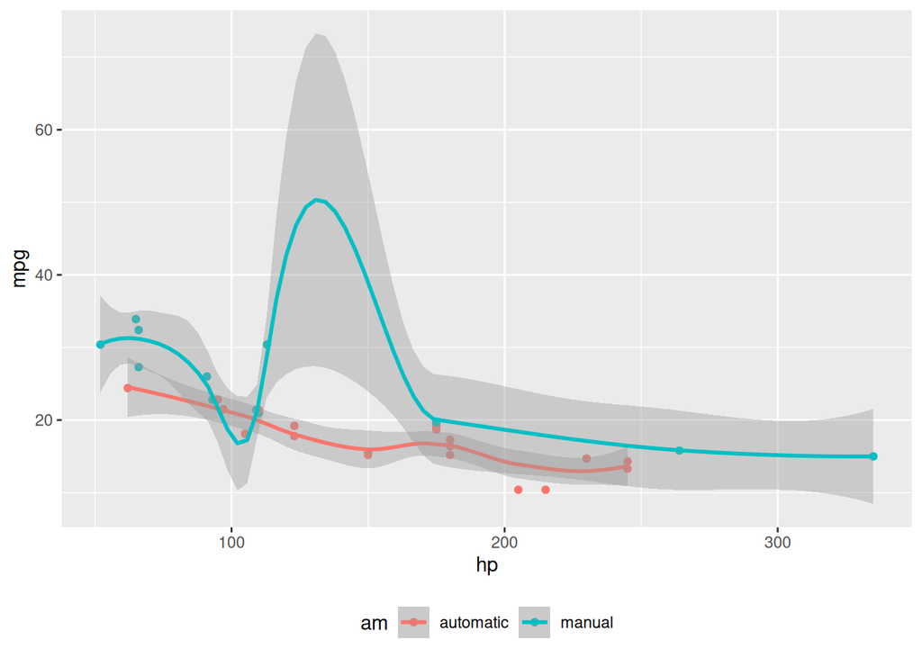

Figura 1: MPG vs horsepower, colored by transmission.

````markdown
```{r}
#| label: fig-margin
#| fig-cap: "MPG vs horsepower, colored by transmission."
#| column: margin
#| message: false
library(ggplot2)
mtcars2 <- mtcars
mtcars2$am <- factor(
  mtcars$am, labels = c('automatic', 'manual')
)
ggplot(mtcars2, aes(hp, mpg, color = am)) +
  geom_point() + geom_smooth() +
  theme(legend.position = 'bottom')
```
````

Fíjate en el uso de la opción `fig-cap` para insertar un *caption* bajo la figura. Se puede ajustar las proporciones de la figura usando las opciones de bloque de código`fig-width` y `fig-height` que ya hemos presentado antes. Las dimensiones se especifican en pulgadas y se escalarán automáticamente para encajar en las dimensiones del margen del documento.

## Contenido arbitrario en el margen

Se puede incluir cualquier contenido en el margen del documento sin más que aplicar la clase de estilo `.column-margin` sobre el elemento. Puedes ver un ejemplo a la derecha de este texto, en el que se reproduce la ecuación del teorema fundamental del Cálculo.

Sabemos por el *primer teorema fundamental del Cálculo* que para $x$ en $[a, b]$:

$$\frac{d}{dx}\left( \int_{a}^{x} f(u)\,du\right)=f(x).$$

## Figuras con anchura completa

Se pueden configurar también las figuras para que ocupen el ancho total de la página mediante la opción para el bloque de código fig-column: page-right

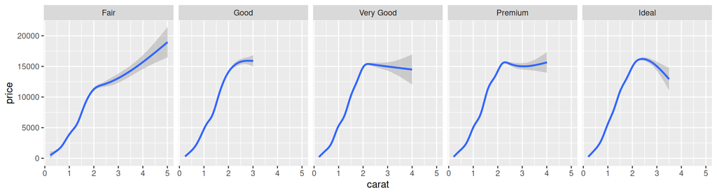

Figura 2: A full width figure.

````markdown
```{r}
#| label: fig-fullwidth
#| fig-cap: "A full width figure."
#| fig-width: 11
#| fig-height: 3
#| fig-column: page-right
#| warning: false
ggplot(diamonds, aes(carat, price)) + geom_smooth() +
  facet_grid(~ cut)
```
````

Otras opciones de *chunk* relacionadas con las figuras se pueden combinar también con esta, como `fig-width`, `fig-cap`, y demás. Para imágenes de anchura completa lo normal es que el valor asigando a `fig-width` sea elevado y `fig-height` tenga un valor menor (figura en formato apaisado). En el ejemplo anterior, el tamaño de la figura es $11 \times 3$.

## Contenido arbitrario a anchura completa

```markdown
::: {.fullwidth}
Any _full width_ content here.
:::
```

Un ejemplo práctico:

*R is free software and comes with ABSOLUTELY NO WARRANTY.* You are welcome to redistribute it under the terms of the GNU General Public License versions 2 or 3. For more information about these matters see https://www.gnu.org/licenses/.

## Figuras en la columna principal

Además de las figuras en el margen y las de anchura completa, también se puede restringir el ancho de la figura al de la columna principal. Este es el tipo de figuras por defecto que aparece en la salida de HTML o PDF.

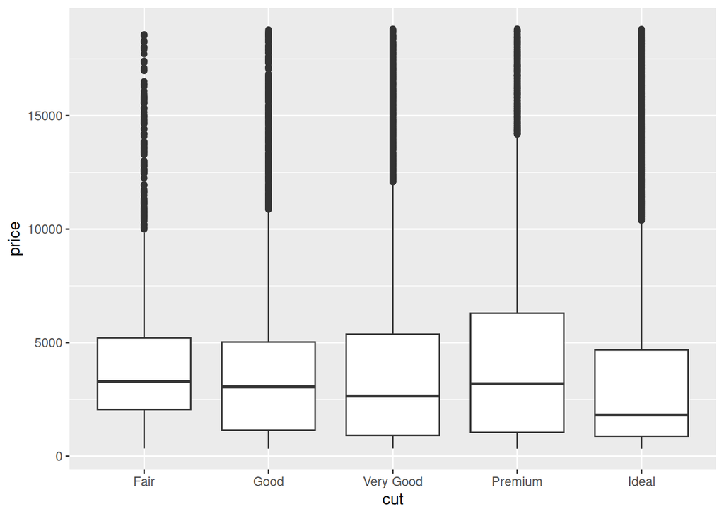

Figura 3: A figure in the main column.

````markdown
```{r}
#| label: fig-main
#| fig-cap: "A figure in the main column."
ggplot(diamonds, aes(cut, price)) + geom_boxplot()
```
````

## *Captions* al margen

Cuando se incluye una figura con anchura limitada a la columna principal, se puede elegir ubicar el caption de la figura en el margen, utilizando la opción `cap-location`. Por ejemplo:

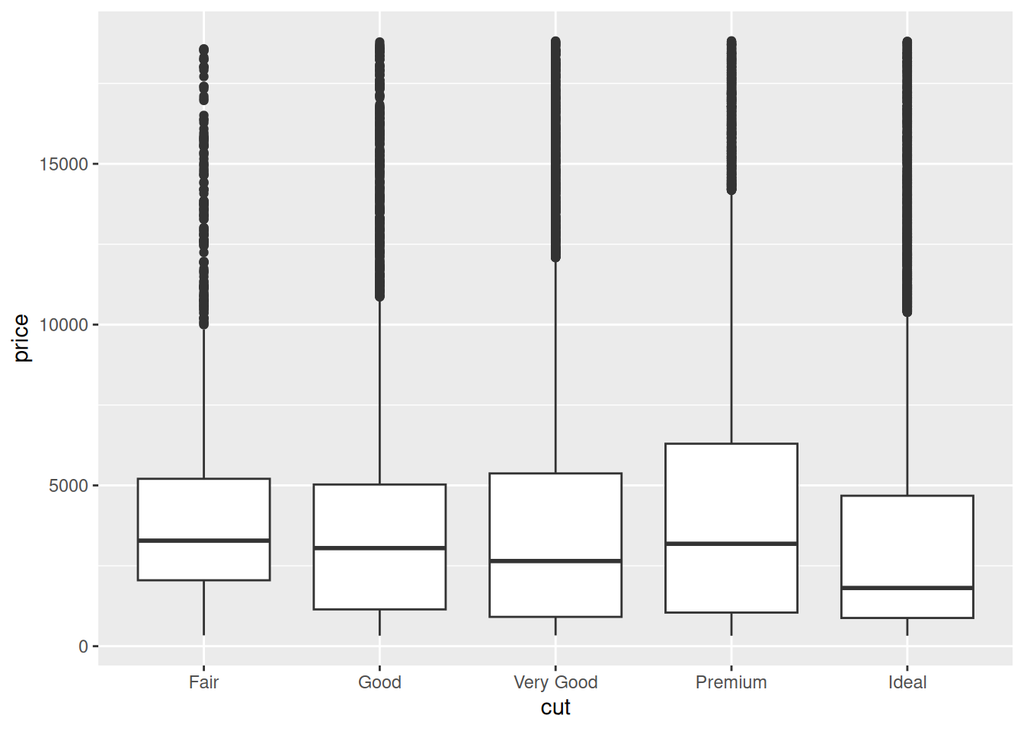

Figura 4: A figure with a longer caption. The figure appears in the main column, but the caption is placed in the margin. Captions can even contain elements like a citation such as Xie, Allaire, y Grolemund (2018).

Xie, Yihui, J. J. Allaire, y Garrett Grolemund. 2018. «Tufte Handouts». En *R Markdown: The Definitive Guide*, 137-46. Chapman; Hall/CRC. https://doi.org/10.1201/9781138359444-6.

````markdown
```{r}
#| label: fig-main-margin-cap
#| fig-cap: "A figure with a longer caption. The figure appears in the main column, but the caption is placed in the margin. Captions can even contain elements like a citation such as @xie2018."
#| cap-location: margin
ggplot(diamonds, aes(cut, price)) + geom_boxplot()
```
````

# Notas al margen

Una de las características más prominentes y distintivas del estilo Tufte es extenso uso de notas al margen. El diseño de la página tiene un amplio espacio en el margen lateral para colocar notas y figuras de pequeño tamaño. Cualquier uso de una nota al pie se convierte automáticamente en una nota al margen.

Si se quiere incluir información complementaria en el margen sin la marca de nota al pie (número en superíndice), se puede aplicar la clase `column-margin` al elemento.

Esto es un área configurada con la clase de estilo `column-margin`, que coloca la nota en el margen del documento sin una marca de nota al margen.

# Referencias bibliográficas

Las referencias se pueden mostrar también como notas al margen en la salida en HTML. Por ejemplo, podemos citar R aquí (R Core Team 2021).

R Core Team. 2021. *R: A Language and Environment for Statistical Computing*. Vienna, Austria: R Foundation for Statistical Computing. https://www.R-project.org/.

Esta característica depende de la opción `link-citations` para localizar y ubicar las referencias en el margen. Esto se habilita por defecto, por lo que si deshabilitamos la opción `link-citations` en la salida HTML entonces las referencias volverán a colocarse al final del documento de salida, como se haría en un documento de Quarto con estilo estándar.

# Tablas

Se puede utilizar la función `kable()` de paquete **knitr** para formatear tablas que se integran bien con el resto del estilo de entrega Tufte. El *caption* de la tabla se coloca en el margen, al igual que ocurre con las figuras en documentos HTML con este estilo.

````markdown
```{r}
#| tbl-cap-location: margin
knitr::kable(
  mtcars[1:6, 1:6], caption = 'A subset of mtcars.'
)
```
````

|  | mpg | cyl | disp | hp | drat | wt |
| --- | --- | --- | --- | --- | --- | --- |
| Mazda RX4 | 21.0 | 6 | 160 | 110 | 3.90 | 2.620 |
| Mazda RX4 Wag | 21.0 | 6 | 160 | 110 | 3.90 | 2.875 |
| Datsun 710 | 22.8 | 4 | 108 | 93 | 3.85 | 2.320 |
| Hornet 4 Drive | 21.4 | 6 | 258 | 110 | 3.08 | 3.215 |
| Hornet Sportabout | 18.7 | 8 | 360 | 175 | 3.15 | 3.440 |
| Valiant | 18.1 | 6 | 225 | 105 | 2.76 | 3.460 |

A subset of mtcars.

# Respuesta dinámica

El diseño de la página en HTML es dinámico, lo que implica que si la página se encoge los elementos ajustarán su posición automáticamente. Los elementos que aparecen en el margen se moverán en línea con el contenido y los que ocupan tanto el cuerpo principal como el margen pasarán a ocupar sólo el cuerpo principal.

# Más ejemplos

El resto de este documento consiste en unos cuantos casos de prueba para asegurarnos de que todo funciona correctamente en escenarios ligeramente más complicados que los que acabamos de describir. Primero, generamos dos gráficos en una misma figura con la opción de *chunk* `fig-show: hold`:

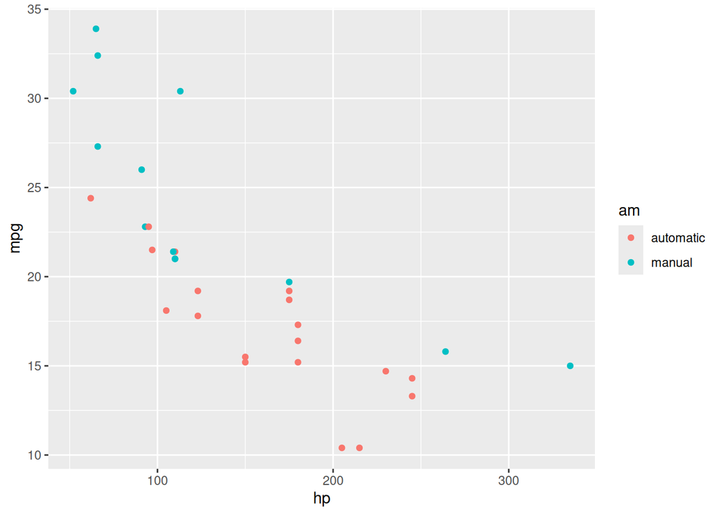

Figura 5: Two plots in one figure environment.

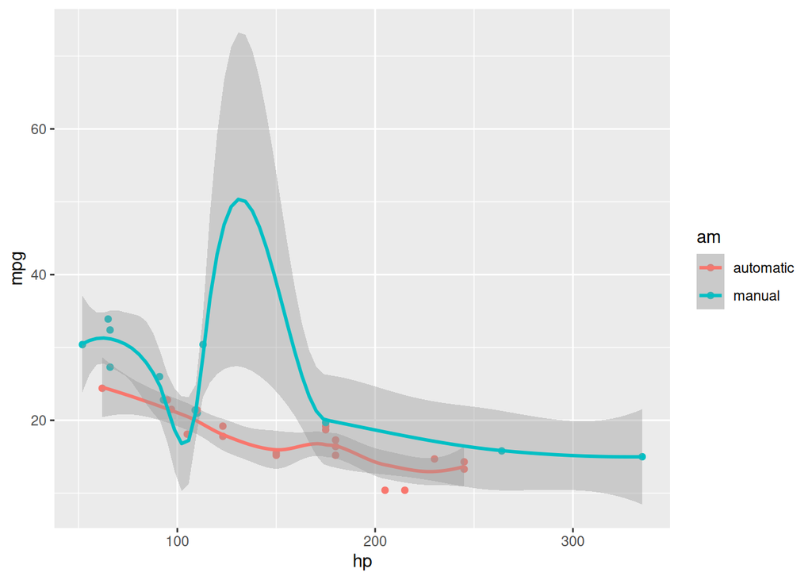

Figura 6: Two plots in one figure environment.

````markdown
```{r}
#| label: fig-two-together
#| fig-cap: "Two plots in one figure environment."
#| fig-show: hold
#| warning: false
#| cap-location: margin
p <- ggplot(mtcars2, aes(hp, mpg, color = am)) +
  geom_point()
p
p + geom_smooth()
```
````

Ahora, dos gráficos en entoros de figura separados (el código es idéntico al del bloque anterior, pero la opción del *chunk* es `fig-show: asis`, el valor por defecto si no ponemos nada):

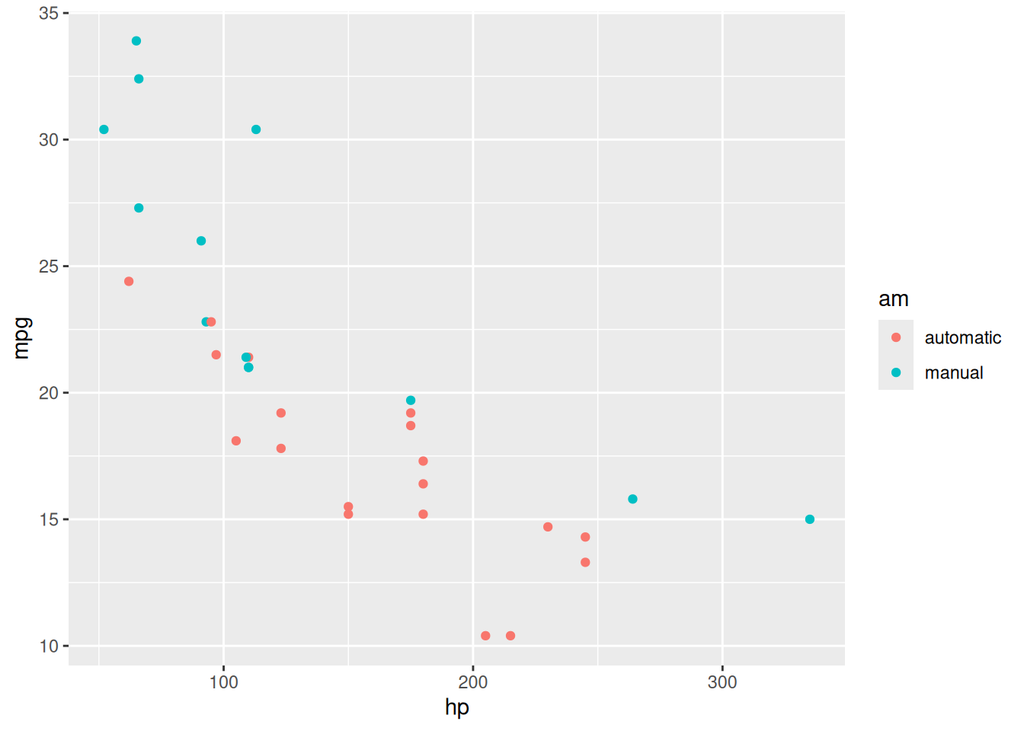

Figura 7: Two plots in separate figure environments (the first plot).

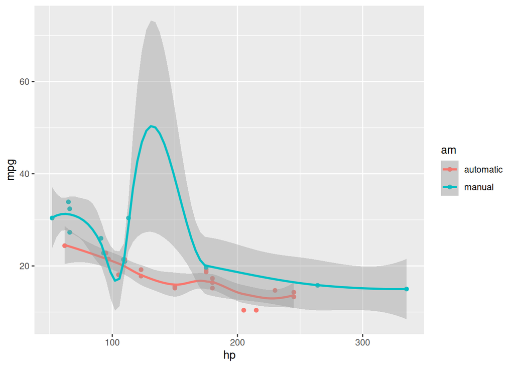

Figura 8: Two plots in separate figure environments (the second plot).

````markdown
```{r fig-two-separate, ref.label='fig-two-together', fig.cap=sprintf("Two plots in separate figure environments (the %s plot).", c("first", "second")), message=FALSE}
#| cap-location: margin
p <- ggplot(mtcars2, aes(hp, mpg, color = am)) +
  geom_point()
p
p + geom_smooth()
```
````

Deberías haberte percatado de que las dos figuras tienen *captions* diferentes, y eso es porque usamos un vector de cadenas de caracteres de longitud 2 para la opción de bloque `fig.cap` (algo como `fig.cap = c('first plot', 'second plot')`).

**Usando R con las opciones de *chunk**

Si deseas emplear expresiones de R en crudo dentro de las opciones de un *chunk* (como en el ejemplo anterior), entonces debes definirlas siguiendo el formato `etiqueta=valor` dentro de las llaves `{r label, tag=value}`, en lugar de la sintaxis de YAML habitual `tag: value`, en una nueva línea que comienza por el símbolo `#|`. La primera aproximación está documentada en el [sitio web de `knitr`](https://yihui.org/knitr/options/) mientras que la segunda está explicada en la [documentación de Quarto](https://quarto.org/docs/reference/cells/cells-knitr.html).

Ahora, mostramos varios gráficos en figuras al margen. De manera similar, dos gráficos en la misma figura en el margen:

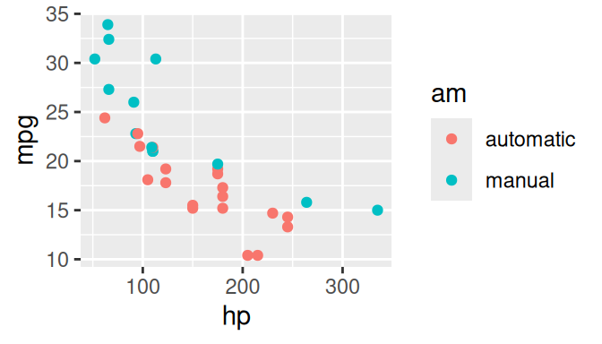

Figura 9: Two plots in one figure environment in the margin.

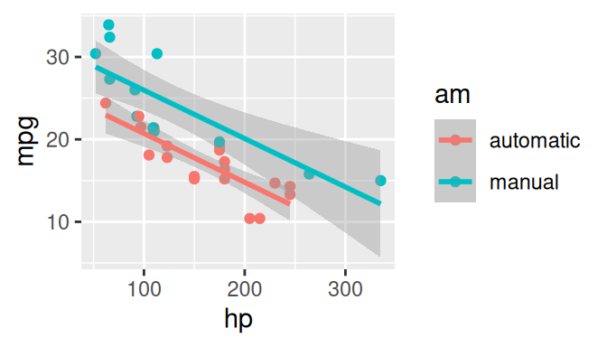

Figura 10: Two plots in one figure environment in the margin.

Dos gráficos del mismo bloque de código colocados en diferentes entornos de figura:

| Sepal.Length | Sepal.Width | Petal.Length | Petal.Width |
| --- | --- | --- | --- |
| 5.1 | 3.5 | 1.4 | 0.2 |
| 4.9 | 3.0 | 1.4 | 0.2 |
| 4.7 | 3.2 | 1.3 | 0.2 |
| 4.6 | 3.1 | 1.5 | 0.2 |
| 5.0 | 3.6 | 1.4 | 0.2 |
| 5.4 | 3.9 | 1.7 | 0.4 |
| 4.6 | 3.4 | 1.4 | 0.3 |
| 5.0 | 3.4 | 1.5 | 0.2 |
| 4.4 | 2.9 | 1.4 | 0.2 |
| 4.9 | 3.1 | 1.5 | 0.1 |
| 5.4 | 3.7 | 1.5 | 0.2 |
| 4.8 | 3.4 | 1.6 | 0.2 |
| 4.8 | 3.0 | 1.4 | 0.1 |

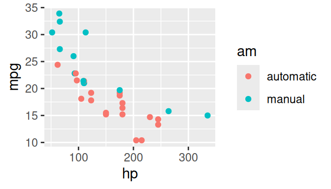

Figura 11: Two plots in separate figure environments in the margin

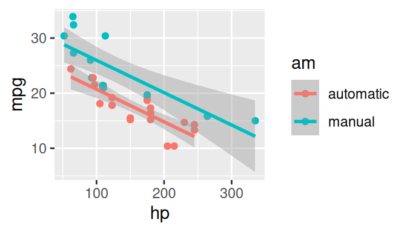

Figura 12: Two plots in separate figure environments in the margin

| Sepal.Length | Sepal.Width | Petal.Length | Petal.Width |
| --- | --- | --- | --- |
| 5.1 | 3.5 | 1.4 | 0.2 |
| 4.9 | 3.0 | 1.4 | 0.2 |
| 4.7 | 3.2 | 1.3 | 0.2 |
| 4.6 | 3.1 | 1.5 | 0.2 |
| 5.0 | 3.6 | 1.4 | 0.2 |
| 5.4 | 3.9 | 1.7 | 0.4 |
| 4.6 | 3.4 | 1.4 | 0.3 |
| 5.0 | 3.4 | 1.5 | 0.2 |
| 4.4 | 2.9 | 1.4 | 0.2 |
| 4.9 | 3.1 | 1.5 | 0.1 |
| 5.4 | 3.7 | 1.5 | 0.2 |

Se han combinado algunas tablas en el bloque de código anterior simplemente como marcadores de espacio, para asegurar que existe suficiente espacio vertical entre las figuras al margen. En caso contrario, las figuras quedarían demasiado juntas unas de otras. Para un documento real, no es recomendable insertar demasiadas figuras al margen conseuctivas, ya que provoca que se apiñen en el margen y genera el efecto visual contrario al que inicialmente se pretende con este diseño.

No es necesario asignar *captions* a las figuras. A continuación se muestran tres ejemplos de figuras ubicadas en distintas posiciones y sin *captions*.

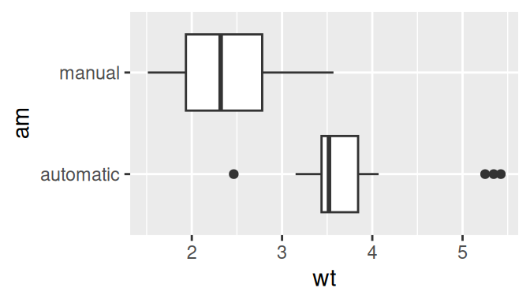

````markdown
```{r}
#| fig-width: 3.5
#| fig-height: 2
#| column: margin
# a boxplot of weight vs transmission; this figure
# will be placed in the margin
ggplot(mtcars2, aes(am, wt)) + geom_boxplot() +
  coord_flip()
```
````

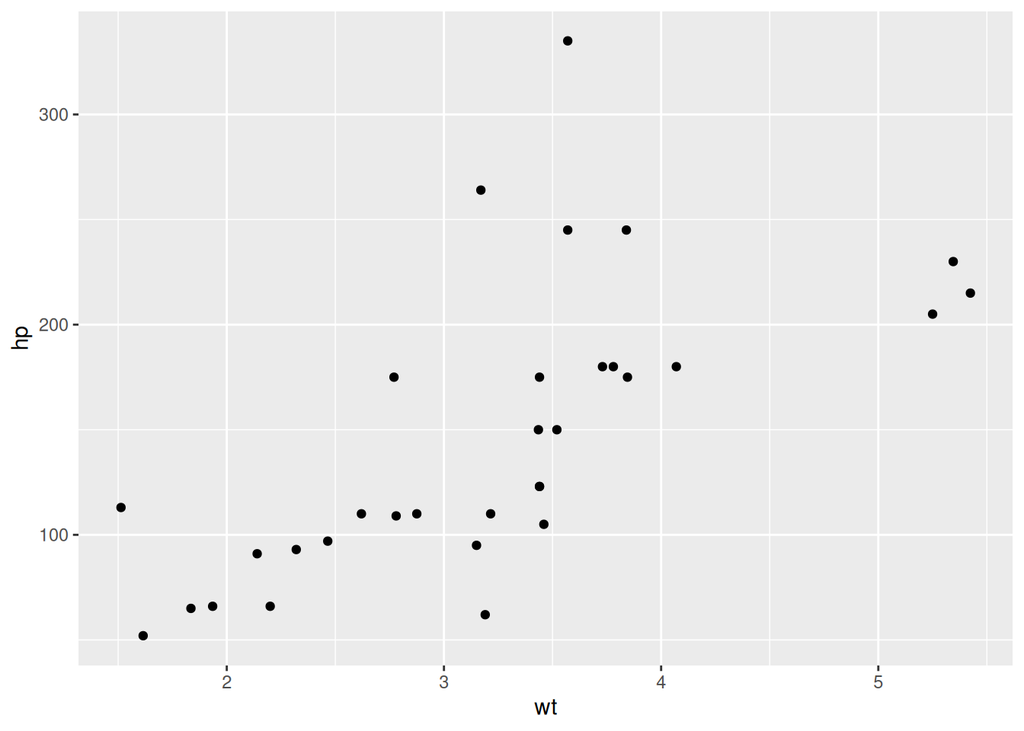

````markdown
```{r}
#| warning: false
# a figure in the main column
p <- ggplot(mtcars, aes(wt, hp)) + geom_point()
p
```
````

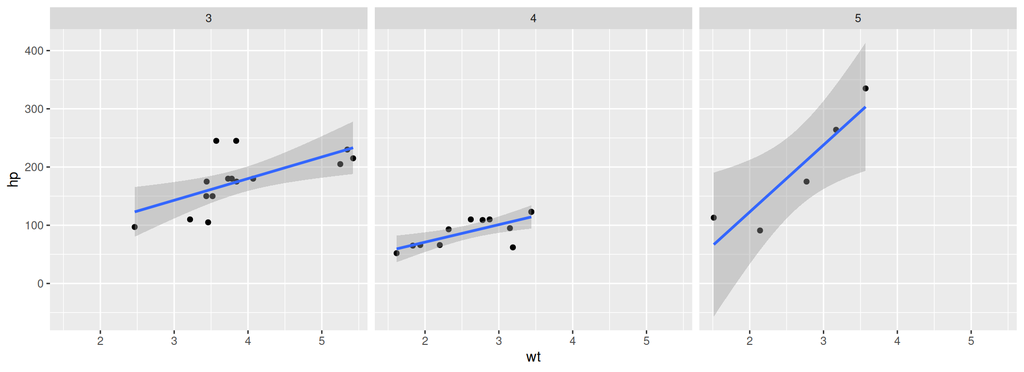

````markdown
```{r}
#| fig-width: 11
#| fig-height: 4
#| column: page-right
#| warning: false
# a fullwidth figure
p + geom_smooth(method = 'lm') + facet_grid(~ gear)
```
````

# Notas adicionales sobre el diseño gráfico de las páginas

El archivo fuente de este documento está [disponible en este enlace al repositorio de código en GitHub](https://raw.githubusercontent.com/quarto-dev/quarto-gallery/main/page-layout/tufte.qmd).